# R Notes for Beginners

## 4.3 Find the mean, variance and standard deviation of character height

```r
sw_height_mean <- mean(starwars$height)
# the default in the mean function is to NOT remove NA values

sw_height_mean_removeNA <- mean(starwars$height, na.rm = TRUE)
# use ?starwars in the console to more info about the dataset and the units of height

# variance of character height (var())
sw_height_variance <- var(starwars$height, na.rm = TRUE)

# standard deviation of character height (sd())
sw_height_sd <- sd(starwars$height, na.rm = TRUE)
```

#### 4.3.0.1 add text that includes a calculated output

Mean character height is 174.4 cm with a standard deviation of 34.8 cm.

## 4.4 janitor::get_dupes()

will check for duplicates across all variables unless you specify variables

```r
starwars_dupes <- get_dupes(starwars)
```

```
## No variable names specified - using all columns.
```

```
## No duplicate combinations found of: name, height, mass, hair_color, skin_color, eye_color, birth_year, sex, gender, ... and 5 other variables
```

```r
starwars_dupes_names <- starwars %>%
  get_dupes(name)
```

```
## No duplicate combinations found of: name
```

```r
starwars_dupes_height <- starwars %>%
  get_dupes(height)
```

### 4.4.1 dplyr::across()

allows you to perform operations across multiple columns based on conditions you specify about the columns

```r
# convert anything that's a character to lower case
sw_across <- starwars %>%
  mutate(across(where(is.character), tolower))
```

Find the mean of all numeric columns

```r
starwars %>%
  group_by(homeworld) %>%
  summarise(across(where(is.numeric), mean, na.rm = TRUE))
```

```
## # A tibble: 49 × 4
##    homeworld      height  mass birth_year
##    <chr>           <dbl> <dbl>      <dbl>
##  1 Alderaan         176.  64           43
##  2 Aleen Minor       79   15          NaN
##  3 Bespin           175   79           37
##  4 Bestine IV       180  110          NaN
##  5 Cato Neimoidia   191   90          NaN
##  6 Cerea            198   82           92
##  7 Champala         196  NaN          NaN
##  8 Chandrila        150  NaN           48
##  9 Concord Dawn     183   79           66
## 10 Corellia         175   78.5         25
## # … with 39 more rows
```

Separate a column into multiple columns based on a delimiter

```r
starwars %>%
  separate(skin_color, into = c("col_1", "col_2"), sep = ",")
```

```
## # A tibble: 87 × 15
##    name    height  mass hair_color col_1 col_2 eye_color birth_year sex   gender
##    <chr>    <int> <dbl> <chr>      <chr> <chr> <chr>          <dbl> <chr> <chr>
##  1 Luke S…    172    77 blond      fair   <NA> blue            19   male  mascu…
##  2 C-3PO      167    75 <NA>       gold   <NA> yellow         112   none  mascu…
##  3 R2-D2       96    32 <NA>       white " bl… red             33   none  mascu…
##  4 Darth …    202   136 none       white  <NA> yellow          41.9 male  mascu…
##  5 Leia O…    150    49 brown      light  <NA> brown           19   fema… femin…
##  6 Owen L…    178   120 brown, gr… light  <NA> blue            52   male  mascu…
##  7 Beru W…    165    75 brown      light  <NA> blue            47   fema… femin…
##  8 R5-D4       97    32 <NA>       white " re… red             NA   none  mascu…
##  9 Biggs …    183    84 black      light  <NA> brown           24   male  mascu…
## 10 Obi-Wa…    182    77 auburn, w… fair   <NA> blue-gray       57   male  mascu…
## # … with 77 more rows, and 5 more variables: homeworld <chr>, species <chr>,
## #   films <list>, vehicles <list>, starships <list>
```

```r
penguins_column_changes <- penguins %>%
  mutate(across(where(is.numeric), as.character)) %>% # change all numeric variables to characters
  mutate(island = fct_relevel(island, c("Dream", "Biscoe", "Torgersen"))) %>% # order items into factor levels
  unite(island_yr, c(island, year), sep = "_") %>% # combine columns
  filter(species %in% c("Adelie", "Chinstrap")) %>% # filter items included in a vector (but not necessarily in that order)
  relocate(sex, .after = species) %>% # relocate columns
  rename(penguin_spp = species) # rename a column header
```

Storing specific things from a data frame

```r
mack_verts <- read_csv(here("data", "AS00601.csv")) %>%
  clean_names()
### store the 5th value in column "weight" as `mc_wt_5`
mc_wt_5 <- mack_verts$weight[5]
# store the values in position 8 through 20
mc_length_8_20 <- mack_verts$length1[8:20] #
### store everything in column `sampledate` as a vector called mc_dates
mc_dates <- mack_verts$sampledate
```

## 4.5 Make a salamander subset

```r
mc_salamanders <- mack_verts %>%
  filter(species == "DITE")

mc_all_salamanders <- mack_verts %>%
  filter(species != "ONCL")

mc_rhol <- mack_verts %>%
  filter(species == "RHOL")
```

# 5 Filtering and Selecting from Data Frames

```r
# use filter to create subset of data based on certain rows. Use pipe operator to perform things in sequence (and then)
# pipe shortcut: command + shift + M
adelies <- penguins %>% # start with penguins then do this... Use two equal signs because you are asking "is equal?"
  filter(species == "Adelie") %>%  # don't need to write the data frame because you already piped it in
  mutate(body_mass_kg = body_mass_g / 1000) # used one equal sign because we are assigning, not asking if equal
unique(adelies$species) # check that the subset only has Adelies
```

```
## [1] Adelie
## Levels: Adelie Chinstrap Gentoo
```

## 5.1 summary statistics for a filtered data frame

```r
toolik_biochem <- read_csv(here("data", "2011_Kling_Akchem.csv"), na = ".") %>%
  janitor::clean_names()
inlet_biochem <- toolik_biochem %>%
  filter(site == "Toolik Inlet" | site == "Toolik inlet") %>% # filter using OR
  select(p_h, doc_u_m, tdn_u_m) # select specific columns

inlet_biochem_summary <- inlet_biochem %>%
  summarize(mean_ph = mean(p_h, na.rm = TRUE), # don't include blank values
            mean_doc = mean(doc_u_m, na.rm = TRUE),
            mean_tdn = mean(tdn_u_m, na.rm = TRUE))

mean_biochem <- vector(mode = "numeric", length = ncol(inlet_biochem))
for (i in 1:ncol(inlet_biochem)) {
  mean_val <- mean(inlet_biochem[[i]], na.rm = TRUE)
  mean_biochem[[i]] <- mean_val
}
```

# 6 Conditional statements & for loops

## 6.1 Conditional statements

```r
pm2_5 <- 248
if (pm2_5 < 100) {
  print("low to moderate risk")
} else if (pm2_5 >= 100 & pm2_5 < 150) {
  print("unhealthy for sensitive groups")
} else {
  print("health risk present")
}
```

```
## [1] "health risk present"
```

```r
species <- "blue whale"
if (str_detect(species, "whale")) {
  print("You found a whale!")
} else {
  print("better luck next time")
}
```

```
## [1] "You found a whale!"
```

```r
max_airtemp_c <- 24.1
if (max_airtemp_c > 27) {
  print("temperature too high")
} else {
  print("temperature OK")
}
```

```
## [1] "temperature OK"
```

```r
base_burrito <- 6.50
main_ingredient <- "veggie"
switch(main_ingredient,
       "veggie" = print(base_burrito),
       "chicken" = print(base_burrito + 3.00),
       "steak" = print(base_burrito + 3.25))
```

```
## [1] 6.5
```

```r
# type ?str_detec in the console to learn more. It's in the stringr package which is in the tidyverse
sbc_observations <- c("blue whale", "gray whale", "whale", "gray wale", "dolphin", "sea lion", "blue whale")
str_detect(sbc_observations, pattern = "whale")
```

```
## [1]  TRUE  TRUE  TRUE FALSE FALSE FALSE  TRUE
```

```r
# an example of str_detect() within a conditional statement
phrase <- "I reallly love data science!"
if (str_detect(phrase, "data")) {
  print("cool")
}
```

```
## [1] "cool"
```

```r
# if-else statements
pika <- 45
if (pika > 60) {
  print("large pike")
} else {
  print("small pika")
}
```

```
## [1] "small pika"
```

## 6.2 For loops

```r
fish <- c(8, 10, 12, 23)
total_fish <- sum(fish)
percent_pop <- vector(mode = "numeric", length = length(fish))
for (i in seq_along(fish)) {
  fishy_fish <- 100 * fish[i] / total_fish
  percent_pop[i] <- fishy_fish
}
percent_pop
```

```
## [1] 15.09434 18.86792 22.64151 43.39623
```

```r
month.name
```

```
##  [1] "January"   "February"  "March"     "April"     "May"       "June"
##  [7] "July"      "August"    "September" "October"   "November"  "December"
```

```r
months <- c(month.name)
seq_along(months)
```

```
##  [1]  1  2  3  4  5  6  7  8  9 10 11 12
```

```r
for (i in seq_along(months)) {
  print(paste(months[i], "is month", i))
}
```

```
## [1] "January is month 1"
## [1] "February is month 2"
## [1] "March is month 3"
## [1] "April is month 4"
## [1] "May is month 5"
## [1] "June is month 6"
## [1] "July is month 7"
## [1] "August is month 8"
## [1] "September is month 9"
## [1] "October is month 10"
## [1] "November is month 11"
## [1] "December is month 12"
```

```r
species <- "dog"
switch(species,
       "cat" = print("meow"),
       "lion" = print("roar"),
       "owl" = print("screech"),
       "fox" = print("obnmoxious"),
       print("something else"))
```

```
## [1] "something else"
```

```r
vec <- seq(from = 0, to = 12, by = 0.5)
length(vec)
```

```
## [1] 25
```

```r
bats <- c(0, -1, 2, 1000, 500, 6)
seq_along(bats)
```

```
## [1] 1 2 3 4 5 6
```

```r
tigers <- c(29, 34, 82)
lions <- c(2, 18, 6)
big_cats <- vector(mode = "numeric", length = length(tigers))

for (i in seq_along(tigers)) {
  total_cats <- tigers[i] + lions[i]
  big_cats[i] <- total_cats
}
big_cats
```

```
## [1] 31 52 88
```

```r
seq_along(tigers)
```

```
## [1] 1 2 3
```

```r
animal <- c("cat", "dog", "dog", "zebra", "dog")
for (i in seq_along(animal)) {
  if (animal[i] == "dog") {
    print("I love dogs")
  } else
    print("these are other animals")
}
```

```
## [1] "these are other animals"
## [1] "I love dogs"
## [1] "I love dogs"
## [1] "these are other animals"
## [1] "I love dogs"
```

```r
mean_mtcars <- vector(mode = "numeric", length = ncol(mtcars))

for (i in 1:ncol(mtcars)) {
  mean_val <- mean(mtcars[[i]], na.rm = TRUE)
  mean_mtcars[[i]] <- mean_val
}
mean_mtcars
```

```
##  [1]  20.090625   6.187500 230.721875 146.687500   3.596563   3.217250
##  [7]  17.848750   0.437500   0.406250   3.687500   2.812500
```

```r
# ncol() returns the number of columns in a data frame
```

```r
animal <- c("cat", "dog", "dog", "car", "zebra", "elephant")
for (i in seq_along(animal)) {
  if (animal[i] == "dog") {
    print("I love dogs")
} else {
    print("this is a different animal")
  }
}
```

```
## [1] "this is a different animal"
## [1] "I love dogs"
## [1] "I love dogs"
## [1] "this is a different animal"
## [1] "this is a different animal"
## [1] "this is a different animal"
```

```r
species <- c("dog", "elephant", "goat", "dog", "dog", "elephant")
age_human_years <- c(3, 8, 4, 6, 12, 18)
animal_ages <- vector(mode = "numeric", length = length(species))

for (i in seq_along(species)) {
  if (species[i] == "dog") {
    animal_ages <- age_human_years[i]*7
  } else if (species[i] == "elephant") {
    animal_ages <- age_human_years[i] * 0.88
  } else if (species[i] == "goat") {
      animal_ages <- age_human_years[i] * 4.7
  }
  animal_ages[i] <- animal_ages
}
```

# 7 gg plot

- tell it you’re using ggplot
- tell it what data you are using and what data you are plotting
- map a variable to an aesthetic
- tell the graph the type of geometry to create

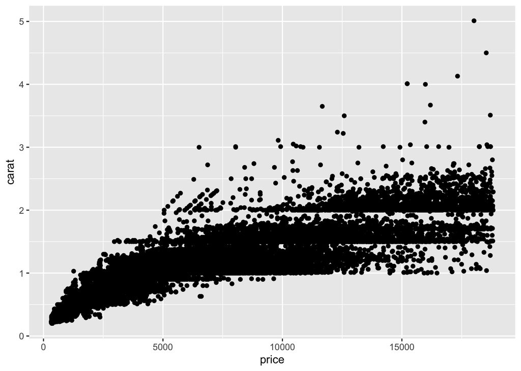

```r
ggplot(data = diamonds, aes(x = price, y = carat)) +
  geom_point()
```

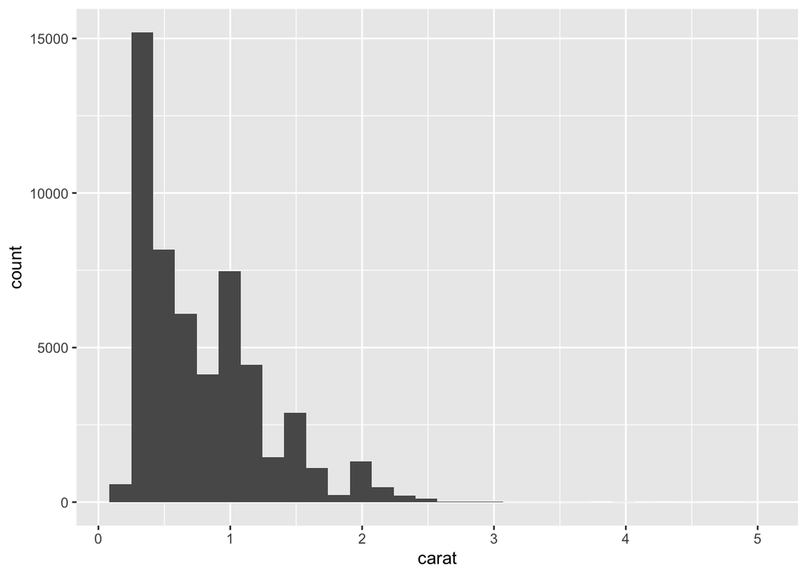

```r
ggplot(data = diamonds, aes(x = carat)) +
  geom_histogram() # histograms only need 1 variable
```

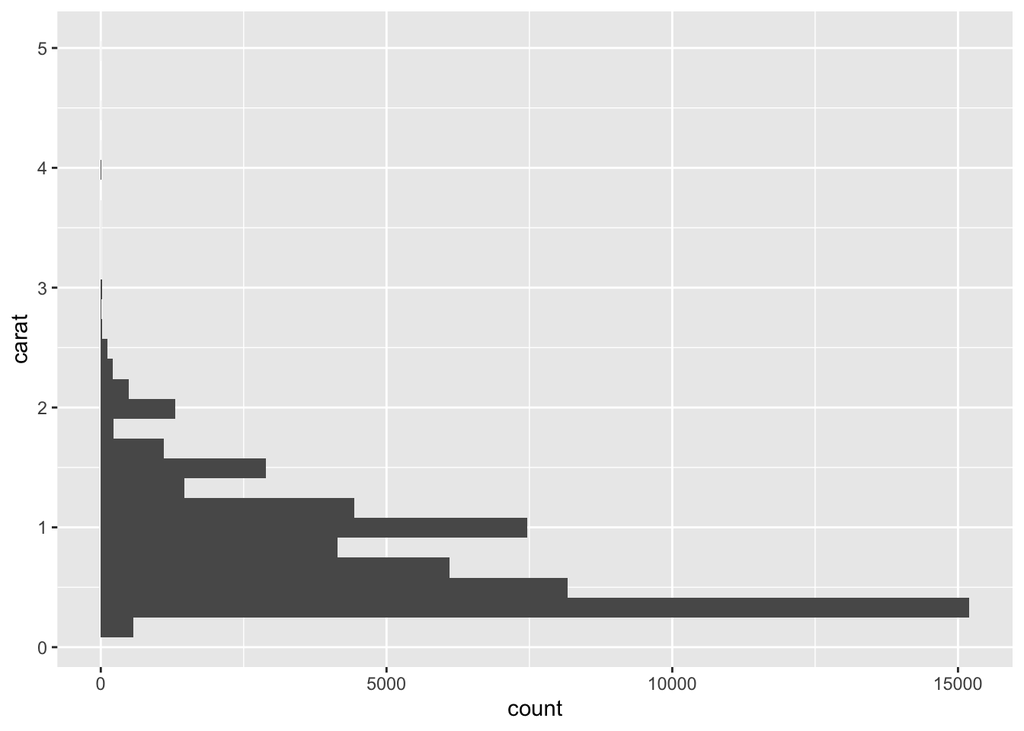

```r
ggplot(data = diamonds, aes(y = carat)) +
  geom_histogram() # difine the y-axis to have horizaontal bars
```

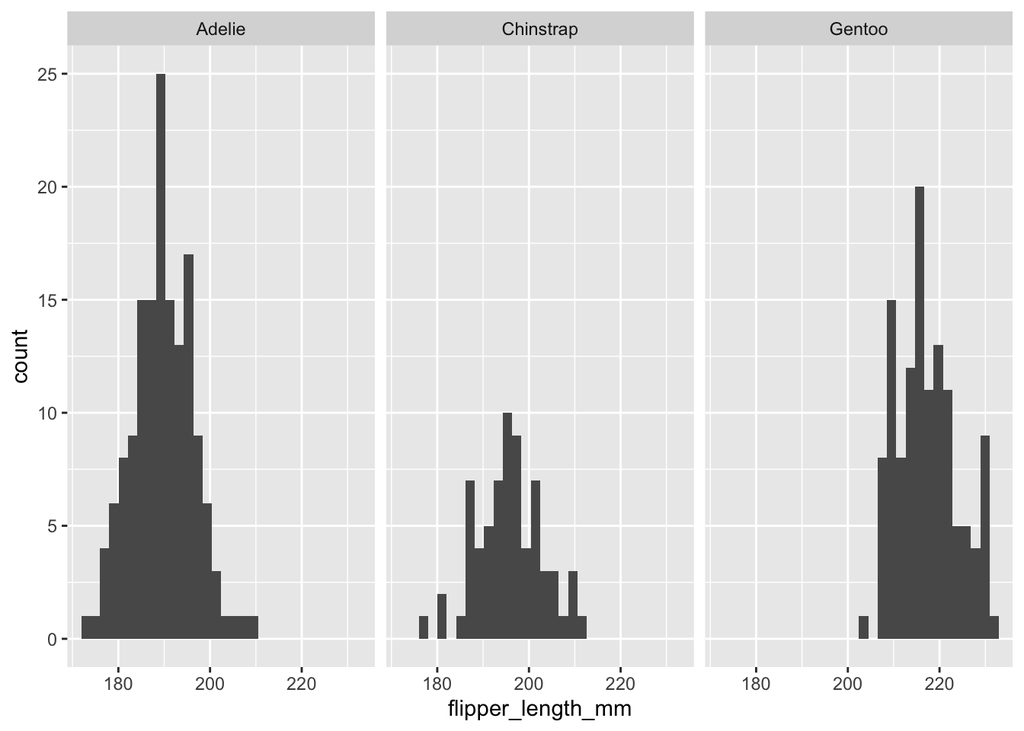

```r
# make a histogram of flipper lenghts
ggplot(data = penguins, aes(x = flipper_length_mm)) +
  geom_histogram() +
  facet_wrap(~species)
```

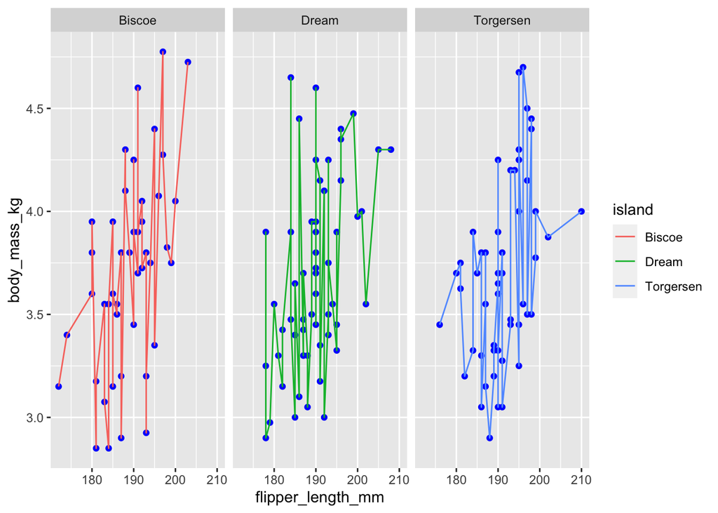

```r
ggplot(data = adelies, aes(x = flipper_length_mm, y = body_mass_kg)) +
  geom_point(color = "blue") +
  geom_line(aes(color = island)) + # connect points with lines
  facet_wrap(~island)
```

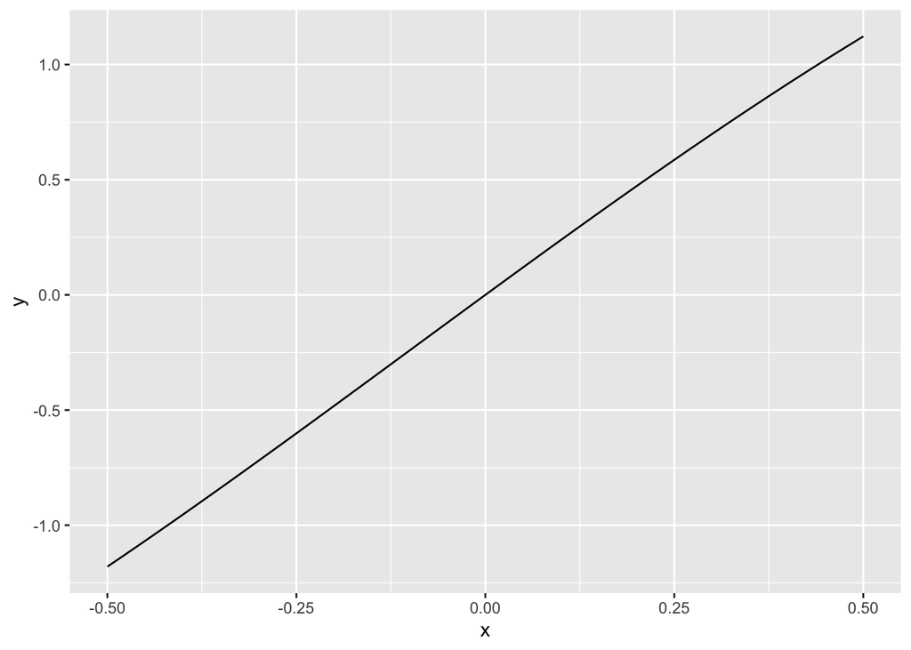

```r
eq_fx <- function(x) {
  (2.4 * (exp(-0.05*x)) * sin(x))
}
ggplot(data = data.frame (x = c(-.5, .5)), aes(x=x)) +
  stat_function(fun = eq_fx)
```

[figure not shown]

```r
# Penguin bill length vs. bill depth
ggplot(data = penguins, aes(x = bill_depth_mm, y = bill_length_mm)) +
  geom_point(aes(color = species)) +
  labs (x = "bill length (mm)",
        y = "bill depth (mm)",
        title = "Palmer penguins bill size",
        caption = "data collected by KB Gorman ey al. at Palmer Station",
        color = "species")
```

Jitter Plot

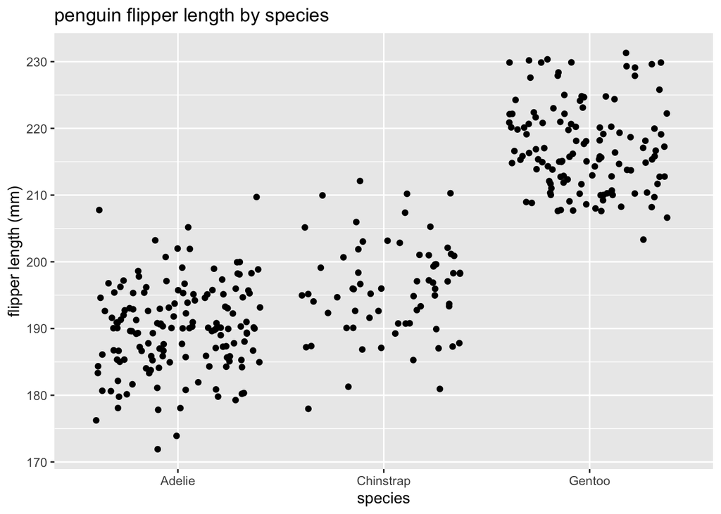

```r
ggplot(data = penguins, aes(x = species, y = flipper_length_mm)) +
  geom_jitter() +
  labs (x = "species",
        y = "flipper length (mm)",
        title = "penguin flipper length by species")
```

change point size based on a variable, make points transparent, reverse y-axis

```r
chlorophyll_plot <- ggplot(data = toolik_chlorophyll, aes(x = active_chl_a_ug_l, y = depth)) +
  geom_point(aes(size = active_chl_a_ug_l),
             color = "cyan",
             alpha = 0.5) +  # makes things transparent
  theme_dark() +
  scale_y_reverse()
```

`ggsave` to saved graphs as figures

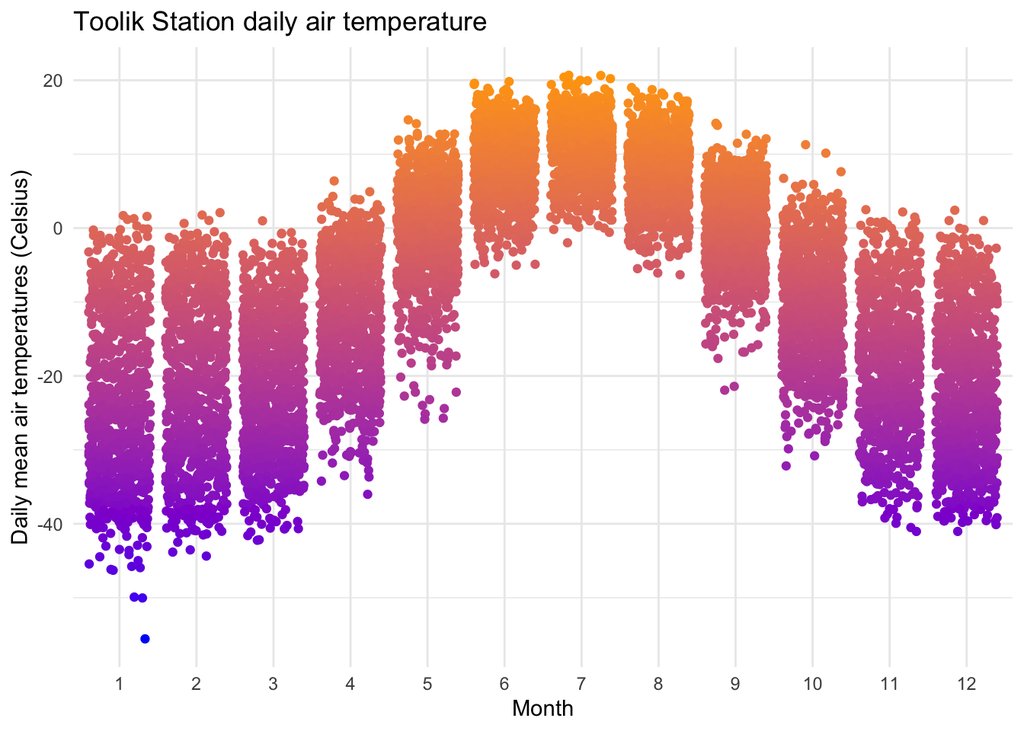

```r
ggsave(here("figs", "chlorophyll_graph.jpg"), plot = chlorophyll_plot)
toolik_weather <- read_csv(here::here("data", "toolik_weather.csv"),
                           na = "#N/A") %>%
  clean_names()
toolik_temp_plot <- ggplot(data = toolik_weather, aes(x = as.factor(month), y = daily_air_temp_mean_c)) + # months in x-axis as factor
  geom_jitter(aes(color = daily_air_temp_mean_c), show.legend = FALSE) + # don't show legend
  scale_color_gradient(low = "blue", high = "orange") +
  theme_minimal() +
  labs(title = "Toolik Station daily air temperature",
       x = "Month",
       y = "Daily mean air temperatures (Celsius)")

toolik_temp_plot
```

```r
ggsave(here("figs", "toolik_temp_plot.png"), height = 6, width = 7) # set dimensions of exported figure
```

# 8 Functions and Loops

```r
weight_grams <- function(a, b, length_cm) {
  weight_grams = (a * (length_cm^b))
}
barracuda <- weight_grams(a = 0.0181, b = 3.27, length_cm = 60)
print(barracuda)
```

```
## [1] 11809.54
```

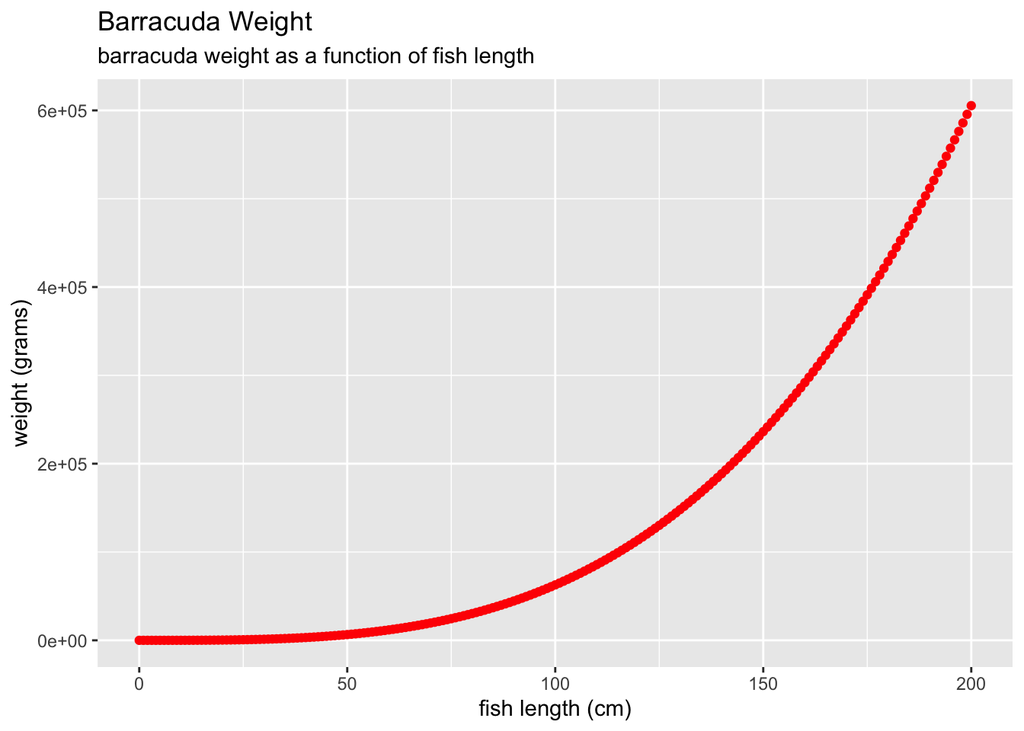

```r
fish_length <- seq(from = 0, to = 200, by = 1)

barracuda_weight <- weight_grams(a = 0.0181, b = 3.27, length_cm = fish_length)
barracuda_df <- data.frame(fish_length, barracuda_weight)

ggplot(data = barracuda_df, aes(x = fish_length, y = barracuda_weight)) +
  geom_point(color = "red") +
  labs(x = "fish length (cm)",
       y = "weight (grams)",
       title = "Barracuda Weight",
       subtitle = "barracuda weight as a function of fish length")
```

# 9 Symbols & Math Operators

## 9.1 Logical Expressions

```r
5 < 10 # true
```

```
## [1] TRUE
```

```r
# greater than and less then work alphabetically (a is small, z is large)
"cat" > "armadillo" # true
```

```
## [1] TRUE
```

```r
"cat" > "elephant" # false
```

```
## [1] FALSE
```

```r
10 <= 11 # true
```

```
## [1] TRUE
```

```r
5 >= 4 # true
```

```
## [1] TRUE
```

```r
3 <= 1 # false
```

```
## [1] FALSE
```

```r
# play around with vectors
tarantulas <- c(1, 3, 7, 10, 15)
tarantulas > 5 # false, false, true, true, true
```

```
## [1] FALSE FALSE  TRUE  TRUE  TRUE
```

```r
pinyon_pine <- 14
pinyon_pine == 10 # does pinyon_pine match a value of 10?
```

```
## [1] FALSE
```

```r
pinyon_pine != 25 # does pinyon_pine NOT match a value of 25
```

```
## [1] TRUE
```

## 9.2 Logical operators:

- `!`
- `&`
- `|`

```r
3 < 1 | 8 > 2
```

```
## [1] TRUE
```

```r
6 < 10 & 5 < 1
```

```
## [1] FALSE
```

```r
7 != 11
```

```
## [1] TRUE
```

```r
4 != 4 | 2 < 5 | 6 > 10
```

```
## [1] TRUE
```

```r
0 == TRUE
```

```
## [1] FALSE
```

```r
0 == FALSE
```

```
## [1] TRUE
```

```r
1 == TRUE #true
```

```
## [1] TRUE
```

```r
# zero is false and 1 is true
```

### 9.2.1 Logarithms `log()`

```r
log(4)
```

```
## [1] 1.386294
```

### 9.2.2 Exponents `exp()`

```r
exp(5)
```

```
## [1] 148.4132
```

```r
log(exp(1))
```

```
## [1] 1
```

### 9.2.3 Derivatives

```r
fx <- expression(x^2)
df_dx <- D(fx, name = 'x')

# Evaluate the slope of f(x) at x = 831
# x <- 831
# evaluate over a range
x <- seq(from = -10, to = 10, by = 0.5)
eval(expr = df_dx)
```

```
##  [1] -20 -19 -18 -17 -16 -15 -14 -13 -12 -11 -10  -9  -8  -7  -6  -5  -4  -3  -2
## [20]  -1   0   1   2   3   4   5   6   7   8   9  10  11  12  13  14  15  16  17
## [39]  18  19  20
```

```r
x <- 831
eval(expr = df_dx)
```

```
## [1] 1662
```

```r
ft <- expression(3 * (t ^ 2) - 4 * cos(t))
df_dt <- D(expr = ft, name = 't')
df_dt
```

```
## 3 * (2 * t) + 4 * sin(t)
```

```r
# First Order univariate derivatives
fx <- expression(x ^ 2)
df_dx <- D(expr = fx, 'x')
df_dx
```

```
## 2 * x
```

```r
x <- 3
eval(expr = df_dx)
```

```
## [1] 6
```

```r
Pa <- expression(2 * (((3 * a) + 2) ^ 4) - 5)
dP_da <- D(expr = Pa, 'a')
dP_da
```

```
## 2 * (4 * (3 * ((3 * a) + 2)^3))
```

```r
a <- 1.2
eval(expr = dP_da)
```

```
## [1] 4214.784
```

```r
gt <- expression((-4 * t) / (((t ^ 2) + 1)  ^ 3))
dg_dt <- D(expr = gt, 't')
dg_dt
```

```
## -(4/(((t^2) + 1)^3) + (-4 * t) * (3 * (2 * t * ((t^2) + 1)^2))/(((t^2) +
##     1)^3)^2)
```

```r
t <- 0
eval(expr = dg_dt)
```

```
## [1] -4
```

```r
# Higher order univariate derivatives
Gz <- expression(4.6 - 1.9 * (z^3))
dG_dz <- D(expr = Gz, 'z')
dG_dz
```

```
## -(1.9 * (3 * z^2))
```

```r
d2G_dz2 <- D(expr = dG_dz, 'z')
d2G_dz2
```

```
## -(1.9 * (3 * (2 * z)))
```

```r
# partial derivatives
f_xyz <- expression(2*x^2*y - 3*x + 1 + 4*z^4*x)
df_dx <- D(expr = f_xyz, 'x')
df_dx
```

```
## 2 * (2 * x) * y - 3 + 4 * z^4
```

```r
df_dy <- D(expr = f_xyz, 'y')
df_dy
```

```
## 2 * x^2
```

```r
dg_dz <- D(expr = f_xyz, 'z')
dg_dz
```

```
## 4 * (4 * z^3) * x
```

# 10 Shortcut Keys

Add a new code chunk: command + option + i

pipe %>%: command + shift + m

run code: command + return highlight specific lines of code to only run those (command + return), but don’t highlight pipes or plus signs

# 11 Rmarkdown formatting

Use back quotes (shift + the button in the top left of the keyboard below esc) to make text appear in code font

# 12 `# Largest header`

## 12.1 `## medium header`

### 12.1.1 `### small header`

#### 12.1.1.1 `#### even smaller header`

##### 12.1.1.1.1 `##### smallest header`

regular text  
*`*italicized font*`*  
**`**bold font**`**  
- `- bullet points`  
- `"tab -" for indented bullet`  
- `"tab tab -" for more indented`

End a line with two spaces to start a new line.  
Or end with a backslash to make a new line `\`

## 12.2 Code chunk options

```r
# adding include = FALSE hides the code chunk when you knit
# ECHO = FALSE hides code
# to hide warnings in knitted output, set warning = FALSE in the beginning of the code chunk
# eval = FALSE means the code wont run (might not let you knit)
```

# 13 Debugging and Troubleshooting

# 14 Miscellaneous

To use git hub, in the console, type usethis::use_git(), then answer yes, they type usethis::use_github(). There might be a more efficient way to add git with a library or something like that.

To upload to github, knit, select the two files, commit, add a comment, commit, pull, close, push

# 15 To Do List

- notes from notebook
- Rmarkdown files from EDS 212
- Rmarkdown files from EDS 221
- EDS 212 class lecture slides
- EDS 221 class lecture slides
  - day 4
  - day 5
  - day 6
  - day 7
  - day 8
  - day 9
  - day 10
  - day 6 interactive
  - favorite dessert
  - icecreamsealion
  - long term ice
  - marie alex meds
  - stl lead
- EDS 221 interactive session
- look at Rstudio cheat sheets and reference guides
- tidyr cheat sheet